# CardioGoodFitness Case study

### Priliminary Data Analysis of customers of the treadmill product(s) of a retail store called Cardio Good Fitness.

#### 1). Notebook uses Python visualization libraries to do Univariate and Multivariate analysis.

#### 2). Dataset in csv holds customer data w.r.t thread mill product of CardioGoodFitness.

#### Author - Varun Raj

```python
# Import All Libraries needed for Data Analysis and Visualization.

import pandas as pd
import numpy as np
import seaborn as sns
import matplotlib.pyplot as plt
```

```python
# Read the dataset in dataframe and check for top 10 records.

Cardiogoodfitness = pd.read_csv("CardioGoodFitness.csv")
Cardiogoodfitness.head(10)
```

|  | Product | Age | Gender | Education | MaritalStatus | Usage | Fitness | Income | Miles |
| --- | --- | --- | --- | --- | --- | --- | --- | --- | --- |
| 0 | TM195 | 18 | Male | 14 | Single | 3 | 4 | 29562 | 112 |
| 1 | TM195 | 19 | Male | 15 | Single | 2 | 3 | 31836 | 75 |
| 2 | TM195 | 19 | Female | 14 | Partnered | 4 | 3 | 30699 | 66 |
| 3 | TM195 | 19 | Male | 12 | Single | 3 | 3 | 32973 | 85 |
| 4 | TM195 | 20 | Male | 13 | Partnered | 4 | 2 | 35247 | 47 |
| 5 | TM195 | 20 | Female | 14 | Partnered | 3 | 3 | 32973 | 66 |
| 6 | TM195 | 21 | Female | 14 | Partnered | 3 | 3 | 35247 | 75 |
| 7 | TM195 | 21 | Male | 13 | Single | 3 | 3 | 32973 | 85 |
| 8 | TM195 | 21 | Male | 15 | Single | 5 | 4 | 35247 | 141 |
| 9 | TM195 | 21 | Female | 15 | Partnered | 2 | 3 | 37521 | 85 |

```python
# Descibe high level statistics of given dataset.

Cardiogoodfitness.describe()
```

|  | Age | Education | Usage | Fitness | Income | Miles |
| --- | --- | --- | --- | --- | --- | --- |
| count | 180.000000 | 180.000000 | 180.000000 | 180.000000 | 180.000000 | 180.000000 |
| mean | 28.788889 | 15.572222 | 3.455556 | 3.311111 | 53719.577778 | 103.194444 |
| std | 6.943498 | 1.617055 | 1.084797 | 0.958869 | 16506.684226 | 51.863605 |
| min | 18.000000 | 12.000000 | 2.000000 | 1.000000 | 29562.000000 | 21.000000 |
| 25% | 24.000000 | 14.000000 | 3.000000 | 3.000000 | 44058.750000 | 66.000000 |
| 50% | 26.000000 | 16.000000 | 3.000000 | 3.000000 | 50596.500000 | 94.000000 |
| 75% | 33.000000 | 16.000000 | 4.000000 | 4.000000 | 58668.000000 | 114.750000 |
| max | 50.000000 | 21.000000 | 7.000000 | 5.000000 | 104581.000000 | 360.000000 |

Mean of the Age group is 28.78.

Middle representation of Age population is between 24 and 33.

Majority of Income group falls between 44K and 58K.

Miles usage representation are significant between 66 and 114.

Fitness ranking is between 1 and 5.

Maximum usage of product in a week 7 times and minimum is 2 times.

Educations years is between 12 and 21.

Income & Miles are highly right skewed and Age is moderatly skewed.

```python
# Identify shape of dataset - rows and columns

Cardiogoodfitness.shape
```

```
(180, 9)
```

There are 9 columns and 180 rows in dataset.

```python
#Information about Meta-data.

Cardiogoodfitness.info()
```

```
<class 'pandas.core.frame.DataFrame'>
RangeIndex: 180 entries, 0 to 179
Data columns (total 9 columns):
 #   Column         Non-Null Count  Dtype
---  ------         --------------  -----
 0   Product        180 non-null    object
 1   Age            180 non-null    int64
 2   Gender         180 non-null    object
 3   Education      180 non-null    int64
 4   MaritalStatus  180 non-null    object
 5   Usage          180 non-null    int64
 6   Fitness        180 non-null    int64
 7   Income         180 non-null    int64
 8   Miles          180 non-null    int64
dtypes: int64(6), object(3)
memory usage: 12.8+ KB
```

Miles,Income,Usage and Education are Continous values.

There are no null values observed.

```python
Cardiogoodfitness.groupby('Product')['Age'].mean()
```

```
Product
TM195    28.55
TM498    28.90
TM798    29.10
Name: Age, dtype: float64
```

Average age group of customers who buys TM798 are 29.10.

### EDA - Univariate Analysis & Multi Variate Analysis

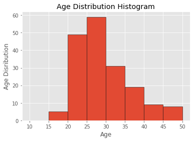

```python
# Using Matplotlib to visualize Age distribution.

plt.style.use('ggplot')
bins = [10, 15, 20, 25, 30, 35, 40, 45, 50]
plt.hist(Cardiogoodfitness.Age, bins=bins, edgecolor='black')

plt.xlabel("Age")
plt.ylabel("Age Disribution")
plt.title("Age Distribution Histogram")
plt.show();
```

It is observed that the majority of customers are between 20 and 30 Age Group.

There are very less customers between age 45 and 50.

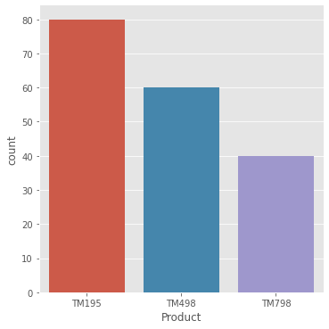

```python
# Using Seaborn to visualize sales by Product category.

sns.catplot(x = 'Product', data = Cardiogoodfitness, kind = 'count');
```

TM195 is the most sold product of count 80 and It is followed by TM498 with count 60. TM798 is the least sold among other two products.

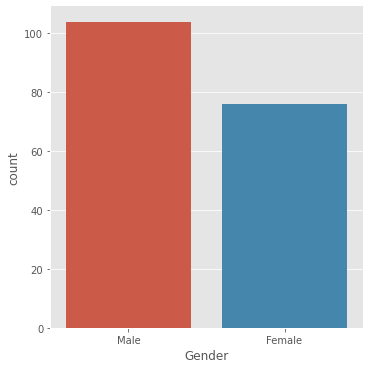

```python
# Using Seaborn to visualize Gender category.


sns.catplot(x = 'Gender', data = Cardiogoodfitness, kind = 'count');
```

It is observed there are more male consumers than female consumers who bought threadmill products from Cardio Good Fitness.

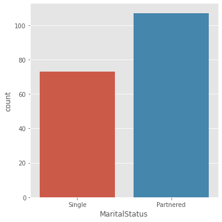

```python
# Using Seaborn to visualize Gender category.


sns.catplot(x = 'MaritalStatus', data = Cardiogoodfitness, kind = 'count');
```

Product consumption is more from couples than singles.

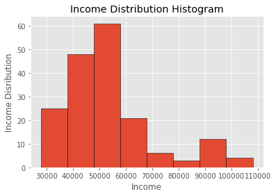

```python
# Using Matplotlib to visualize Income distribution.


plt.style.use('ggplot')
bins = [28000,38000,48000,58000,68000,78000,88000,98000,108000]
plt.hist(Cardiogoodfitness.Income, bins=bins, edgecolor='black')

plt.xlabel("Income")
plt.ylabel("Income Disribution")
plt.title("Income Distribution Histogram")
plt.show();
```

There are less sales purchase from High-income bracket and majority of interests came from Mid-income group.

```python
### Multivariate Analysis
```

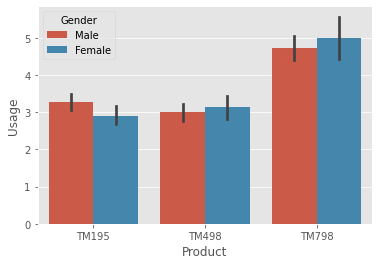

```python
# Using seaborn to visualize Product, Usage and Gender data.

sns.barplot(x=Cardiogoodfitness['Product'], y=Cardiogoodfitness['Usage'], hue = Cardiogoodfitness['Gender']);
```

TM798 has been used most among all the products.

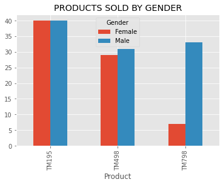

```python
# Visualize products sold by geneder using matplotlib

plt.figure(figsize=(10,10))

pd_gender = pd.crosstab(Cardiogoodfitness['Product'],Cardiogoodfitness['Gender'] )

pd_gender.plot(kind='bar')

plt.title("PRODUCTS SOLD BY GENDER")
```

TM798 is mostly bought by Males customers. TM195 is equally bought by both Male and Female customers.

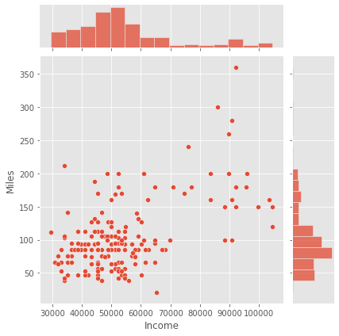

```python
# Using seaborn to visualize Miles, Income data.

sns.jointplot( x = 'Income', y = 'Miles', data = Cardiogoodfitness);
```

There is slight correlation between Income and miles. These can be due to high-income gorup can buy high end product that can be used for long distance.

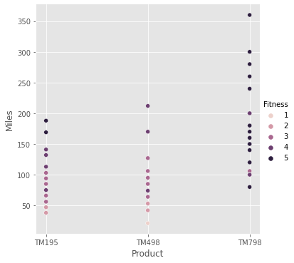

```python
# Using seaborn to visualize Product, Miles and Fitness data.

sns.relplot(x="Product", y="Miles", data=Cardiogoodfitness, hue = "Fitness")
```

Observation & Inference :

It is clearly observed Product TM798 is used by high-fit group and also for long usage of upto 360 miles (miles coverage). TM195 appeared to be used by beginners/moderately-fit groups and used for lower miles coverage upto 180 miles. TM498 comes under mid-segment covers upto 220 miles with customer base similar to TM195.

TM798 can be inferred as high end product.

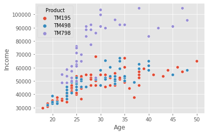

```python
# Using seaborn to visualize Product, Age and Income.

sns.scatterplot(x="Age", y="Income", data=Cardiogoodfitness, hue = "Product")
```

Observation & Inference :

It is observed that high-income group buys significant portion of TM798 and also can be inferred TM798 is expensive of all 3 products. TM195 and TM498 are preferred choice for moderatly and low-income group. There is also correlation that as age increases , average salary is also increases so group under age 22 will mostly opt for TM195 (evident in chart) and its price should be in afforable category.

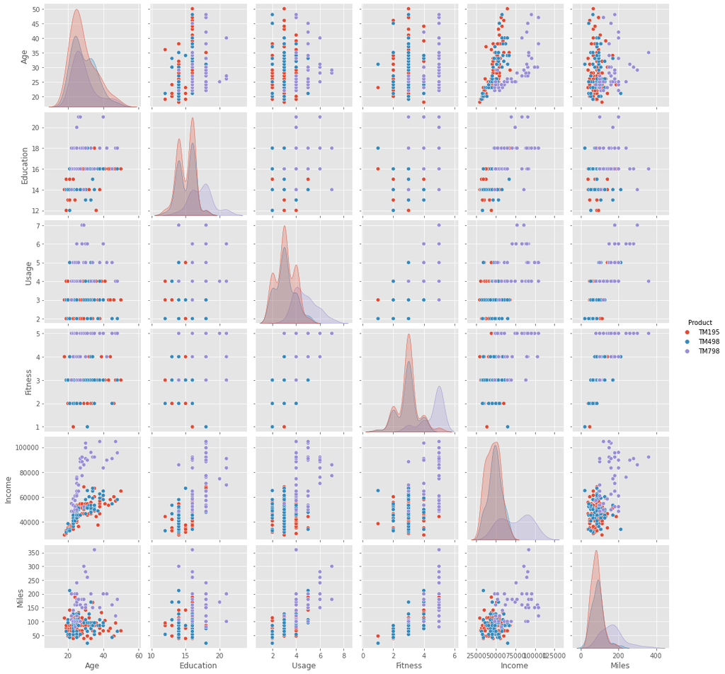

```python
# Using Pairplot for view distribution, skewness, correlation and outliers.

sns.pairplot(Cardiogoodfitness,hue="Product")
```

Observations in scatterplot :

1). There is some positive correlation between Age and Income. 2). There is also some level positive correlation between Miles and Usage similarly Fitness and Usage. 3). There are outliers observed consistently in charts.

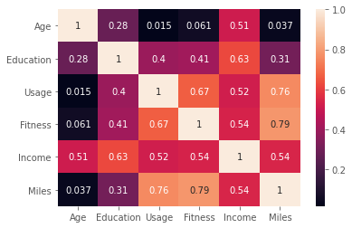

```python
# Using heatmap for correlation.

sns.heatmap(Cardiogoodfitness.corr(), annot=True)
```

Correlation observed between

1). Miles and Usage. 2). Miles and Fitness. 3). Income and education. 4). Fitness and Usage.

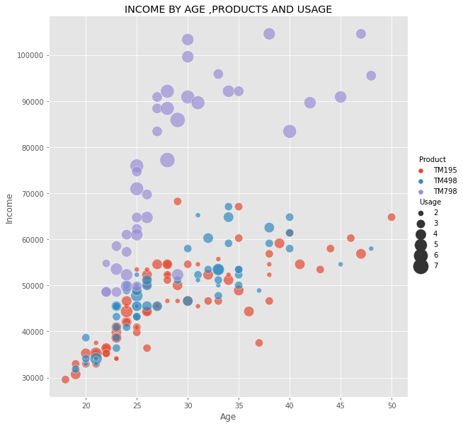

```python
# Using relplot visualtion on Income, Age,Product and Usage

sns.relplot(x="Age", y="Income", hue="Product", size="Usage",
            sizes=(50, 450), alpha=.7,
            height=8, data=Cardiogoodfitness).set(title='INCOME BY AGE ,PRODUCTS AND USAGE');
```

Conclusion

1). TM798 is high end model based on its usage, performance (Miles coverage) and income group of customers.

2). Income data has outliers; High income group prefers TM798 and Low income prefers TM195.

3). TM798's customers average age group is 29 and preferred among male customers.

4). Product sales are better in married group.

5). Active customers group are between 20 and 30.

Recommendation

1).Target customer for TM798 is between 20 and 30 with income range above 60K. This product can be branded as high end segment.

2).Female customers can be target to by TM798 by giving promotions and discounts since they equally shown interests in other TM498 and TM195.

3).Upgrade options given for customers to buy new threadmill from older threadmill from the Cardiogoodfitness. This can help to retain loyal customers.

4). Instalment options can be given to low income group to buy TM498 which can increase sales margin.